# Advanced Stats Assignment4

2023-02-27

### Question 3 Dimension Reduction & Regularization

1. Split the data set into a training set and a test set. Perform a 80:20 split

```r
# Data Overview
head(Boston)
```

```
##      crim zn indus chas   nox    rm  age    dis rad tax ptratio lstat medv
## 1 0.00632 18  2.31    0 0.538 6.575 65.2 4.0900   1 296    15.3  4.98 24.0
## 2 0.02731  0  7.07    0 0.469 6.421 78.9 4.9671   2 242    17.8  9.14 21.6
## 3 0.02729  0  7.07    0 0.469 7.185 61.1 4.9671   2 242    17.8  4.03 34.7
## 4 0.03237  0  2.18    0 0.458 6.998 45.8 6.0622   3 222    18.7  2.94 33.4
## 5 0.06905  0  2.18    0 0.458 7.147 54.2 6.0622   3 222    18.7  5.33 36.2
## 6 0.02985  0  2.18    0 0.458 6.430 58.7 6.0622   3 222    18.7  5.21 28.7
```

```r
# Omit NAs
Boston <- na.omit(Boston)
summary(Boston$crim)
```

```
##     Min.  1st Qu.   Median     Mean  3rd Qu.     Max.
##  0.00632  0.08204  0.25651  3.61352  3.67708 88.97620
```

```r
# Split data
set.seed(9295)
sample_data <- sample(c(TRUE, FALSE), nrow(Boston), replace = TRUE, prob=c(0.8, 0.2))
train <- as.data.frame(Boston[sample_data, ])
test <- as.data.frame(Boston[!sample_data, ])
```

2. Fit a PCR model on the training set, with M chosen by cross-validation. Report the test error obtained, along with the value of M selected by cross-validation.

The test error is 42.22504. The value M selected by cross validation is 12.

```r
# Fit a PCR model
pcr_model <- pcr(crim~., data = train, scale = TRUE, validation = "CV")
summary(pcr_model)
```

```
## Data:    X dimension: 399 12
##  Y dimension: 399 1
## Fit method: svdpc
## Number of components considered: 12
##
## VALIDATION: RMSEP
## Cross-validated using 10 random segments.
##        (Intercept)  1 comps  2 comps  3 comps  4 comps  5 comps  6 comps
## CV           8.697    7.257    7.229    6.874    6.833    6.787    6.774
## adjCV        8.697    7.255    7.227    6.866    6.828    6.783    6.769
##        7 comps  8 comps  9 comps  10 comps  11 comps  12 comps
## CV       6.621    6.635    6.650     6.658     6.602      6.53
## adjCV    6.616    6.630    6.646     6.651     6.592      6.52
##
## TRAINING: % variance explained
##       1 comps  2 comps  3 comps  4 comps  5 comps  6 comps  7 comps  8 comps
## X       50.15    63.46    72.85    80.30    87.11    90.53    93.13    95.09
## crim    30.60    31.27    38.60    39.43    40.25    40.50    43.09    43.23
##       9 comps  10 comps  11 comps  12 comps
## X       96.77     98.33     99.49    100.00
## crim    43.32     43.64     45.13     46.45
```

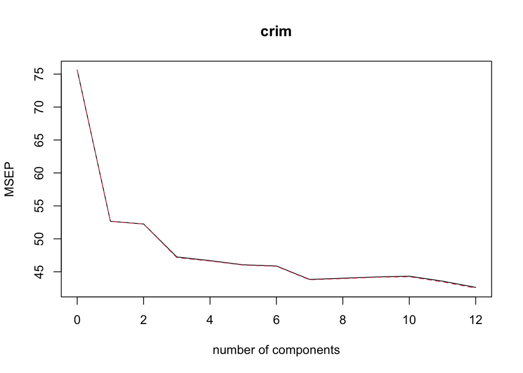

```r
validationplot(pcr_model, val.type = "MSEP")
```

```r
# Save x and y separately
x_train = model.matrix(crim~., train)[,-1]
x_test = model.matrix(crim~., test)[,-1]
y_train = train %>%
  select(crim) %>%
  unlist() %>%
  as.numeric()
y_test = test %>%
  select(crim) %>%
  unlist() %>%
  as.numeric()

# Compute test error
pcr_pred = predict(pcr_model, x_test, ncomp = 12)
mse <- mean((pcr_pred-y_test)^2)
mse
```

```
## [1] 42.22504
```

```r
# Compute accuracy
accuracy <- 1 - mse/var(y_test)
accuracy
```

```
## [1] 0.3877708
```

3. Fit a PLS model on the training set, with M chosen by cross-validation. Report the test error obtained, along with the value of M selected by cross-validation.

The test error is 42.22808. The value M selected by cross validation is 9.

```r
# Fit a PLS model
pls_model <- plsr(crim~., data = train, scale = TRUE, validation = "CV")
summary(pls_model)
```

```
## Data:    X dimension: 399 12
##  Y dimension: 399 1
## Fit method: kernelpls
## Number of components considered: 12
##
## VALIDATION: RMSEP
## Cross-validated using 10 random segments.
##        (Intercept)  1 comps  2 comps  3 comps  4 comps  5 comps  6 comps
## CV           8.697    7.104    6.710    6.644    6.632    6.634    6.622
## adjCV        8.697    7.101    6.704    6.637    6.620    6.620    6.607
##        7 comps  8 comps  9 comps  10 comps  11 comps  12 comps
## CV       6.610    6.602    6.598     6.600     6.600     6.600
## adjCV    6.596    6.589    6.585     6.586     6.587     6.587
##
## TRAINING: % variance explained
##       1 comps  2 comps  3 comps  4 comps  5 comps  6 comps  7 comps  8 comps
## X       49.69    59.47    67.16    74.86    80.96    83.76    88.36    92.22
## crim    34.35    42.52    44.45    45.53    45.91    46.29    46.37    46.43
##       9 comps  10 comps  11 comps  12 comps
## X       94.83     96.53     98.33    100.00
## crim    46.45     46.45     46.45     46.45
```

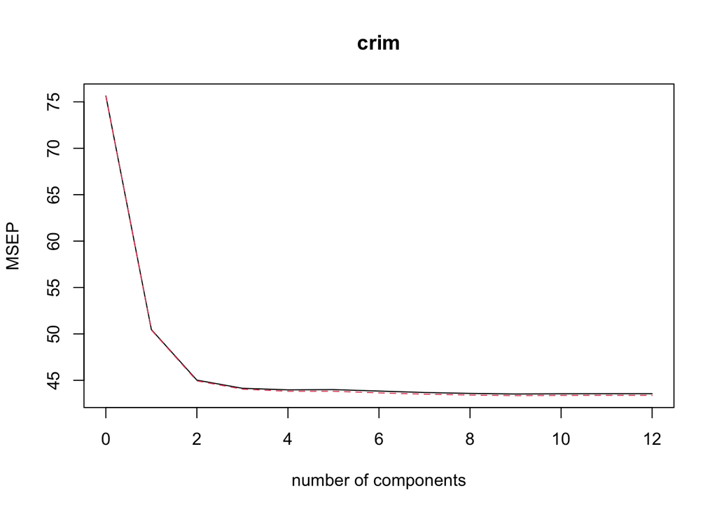

```r
validationplot(pls_model, val.type = "MSEP")
```

```r
# Compute test error
pls_pred = predict(pls_model, x_test, ncomp = 9)
mse <- mean((pls_pred-y_test)^2)
mse
```

```
## [1] 42.22808
```

```r
# Compute accuracy
accuracy <- 1 - mse/var(y_test)
accuracy
```

```
## [1] 0.3877267
```

4. Fit a ridge regression model on the training set, with λ chosen by cross-validation. Report the test error obtained.

The test error is 42.2331. The λ selected by cross validation is 0.5532618.

```r
# Fit a ridge regression model
ridge_model <- glmnet(x_train, y_train, alpha = 0)
summary(ridge_model)
```

```
##           Length Class     Mode
## a0         100   -none-    numeric
## beta      1200   dgCMatrix S4
## df         100   -none-    numeric
## dim          2   -none-    numeric
## lambda     100   -none-    numeric
## dev.ratio  100   -none-    numeric
## nulldev      1   -none-    numeric
## npasses      1   -none-    numeric
## jerr         1   -none-    numeric
## offset       1   -none-    logical
## call         4   -none-    call
## nobs         1   -none-    numeric
```

```r
# Find optimal lambdha
cv_model <- cv.glmnet(x_train, y_train, alpha = 0)
best_lambda <- cv_model$lambda.min
best_lambda
```

```
## [1] 0.5532618
```

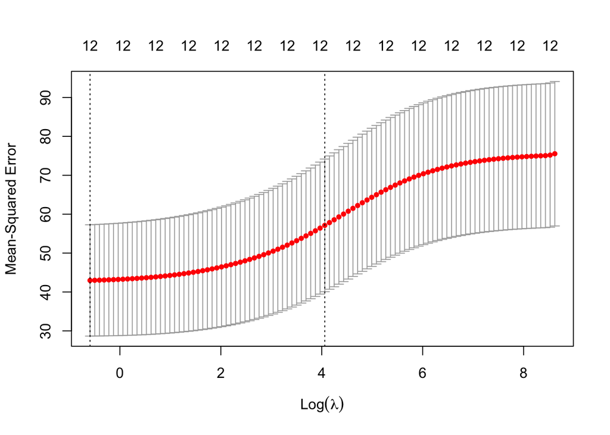

```r
plot(cv_model)
```

```r
# Compute the error
ridge_pred = predict(ridge_model, s = best_lambda, newx = x_test)
mse <- mean((ridge_pred - y_test)^2)
mse
```

```
## [1] 42.2331
```

```r
# Compute accuracy
accuracy <- 1 - mse/var(y_test)
accuracy
```

```
## [1] 0.387654
```

5. Fit a lasso model on the training set, with λ chosen by cross-validation. Report the test error obtained, along with the number of non-zero coefficient estimates.

```r
# Fit a lasso regression model
lasso_model <- glmnet(x_train, y_train, alpha = 1)
summary(lasso_model)
```

```
##           Length Class     Mode
## a0         78    -none-    numeric
## beta      936    dgCMatrix S4
## df         78    -none-    numeric
## dim         2    -none-    numeric
## lambda     78    -none-    numeric
## dev.ratio  78    -none-    numeric
## nulldev     1    -none-    numeric
## npasses     1    -none-    numeric
## jerr        1    -none-    numeric
## offset      1    -none-    logical
## call        4    -none-    call
## nobs        1    -none-    numeric
```

```r
# Find optimal lambdha
cv_model <- cv.glmnet(x_train, y_train, alpha = 1)
best_lambda <- cv_model$lambda.min
best_lambda
```

```
## [1] 0.05281152
```

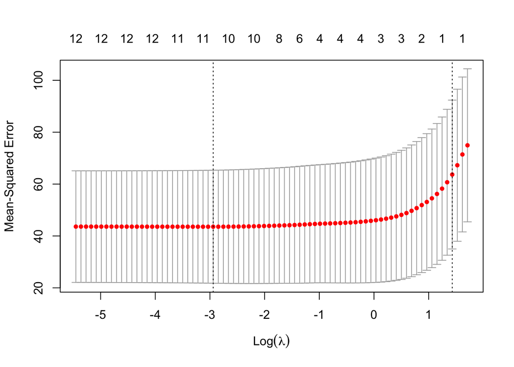

```r
plot(cv_model)
```

```r
# Compute the error
lasso_pred = predict(lasso_model, s = best_lambda, newx = x_test)
mse <- mean((lasso_pred - y_test)^2)
mse
```

```
## [1] 42.13553
```

```r
# Number of non-zero coefficient
lasso_coef = predict(lasso_model, type = "coefficients", s = best_lambda) # Display coefficients using lambda chosen by CV
lasso_coef
```

```
## 13 x 1 sparse Matrix of class "dgCMatrix"
##                      s1
## (Intercept)  9.02300020
## zn           0.03920885
## indus       -0.07420118
## chas        -0.71760181
## nox         -5.94467300
## rm           0.54999990
## age          .
## dis         -0.86653449
## rad          0.53876397
## tax          .
## ptratio     -0.19935458
## lstat        0.10853964
## medv        -0.20527439
```

```r
length(lasso_coef[lasso_coef != 0])
```

```
## <sparse>[ <logic> ]: .M.sub.i.logical() maybe inefficient
```

```
## [1] 11
```

```r
# Compute accuracy
accuracy <- 1 - mse/var(y_test)
accuracy
```

```
## [1] 0.3890687
```

6. Comment on the results obtained. How accurately can we predict the crime rate? Is there much difference among the test errors resulting from these approaches?

There is no much difference among the test errors resulting from these approaches. We can not predict the crime rate accurately using these models. And since Boston data has a high degree of variability and noise, it’s reasonable that we can not fit a linear model to do an accurate prediction.